# EDA with ggplot2

Qu Mengyuan

10/6/2019

# Finding 1

Telemarketing is in highly active state during May and August and extremely active in May while in March, September, Octorber and December it is reletively dormant.

```r
# Find the distribution of last contact month
bank %>%
  mutate(month_n = month(parse_date_time(month, "b"))) %>%
  group_by(month_n) %>%
  summarise(count = n()) -> res
res
```

```
## # A tibble: 12 x 2
##    month_n count
##      <dbl> <int>
##  1       1   148
##  2       2   222
##  3       3    49
##  4       4   293
##  5       5  1398
##  6       6   531
##  7       7   706
##  8       8   633
##  9       9    52
## 10      10    80
## 11      11   389
## 12      12    20
```

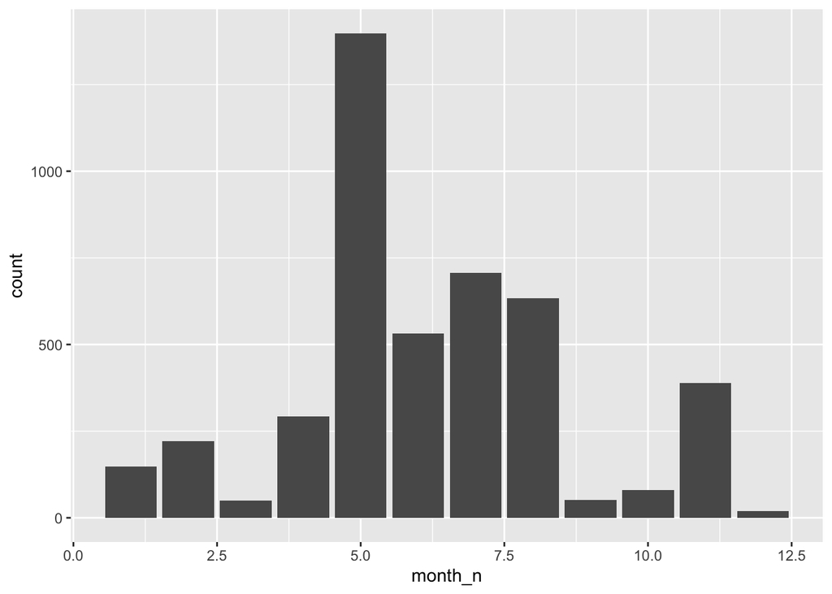

```r
ggplot(res, aes(month_n, count)) + geom_col()
```

# Finding 2

Client’s average yearly balance doen’t has direct relationship with their age.

At the begining of their career, they tend to have a relatively lower balance.

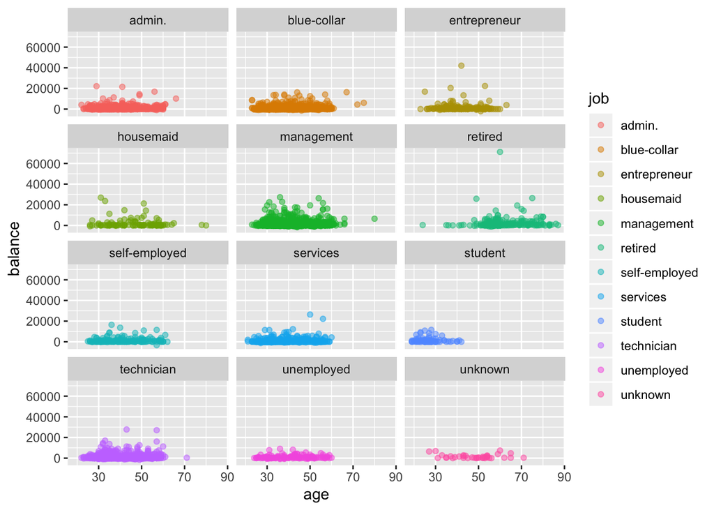

```r
# Find the relationship between age and balance.
ggplot(data = bank) +
  geom_point(mapping = aes(x = age, y = balance, color = job),alpha = 0.5) +
  facet_wrap( ~ job,nrow = 4)
```

# Finding 3

Generally, the higher education a client gets, the stronger willing he has to keep single.

In other words, less education one gets, higher probability he/she is married.

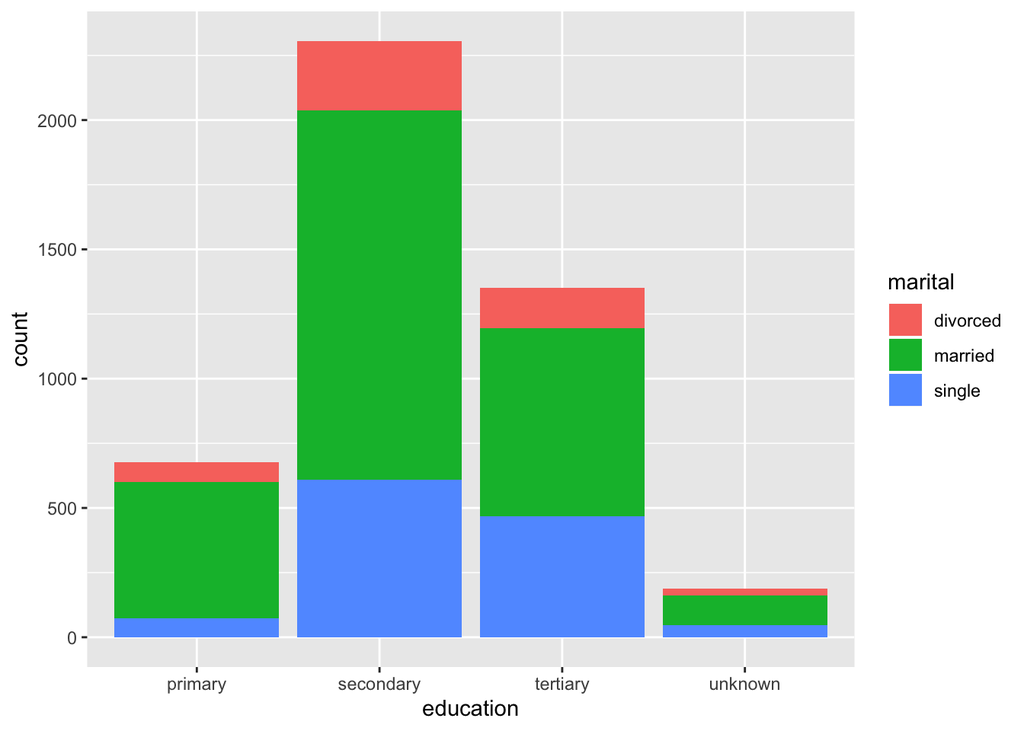

```r
# Find the relationship between marital and education.
ggplot() +
  geom_bar(data = bank, mapping = aes(x = education, fill = marital))
```

# Finding 4

Generally, the higher **education** a client gets, the higher average yearly **balance** he has.

The average yearly balance among clients who have primary education *polarizes*.

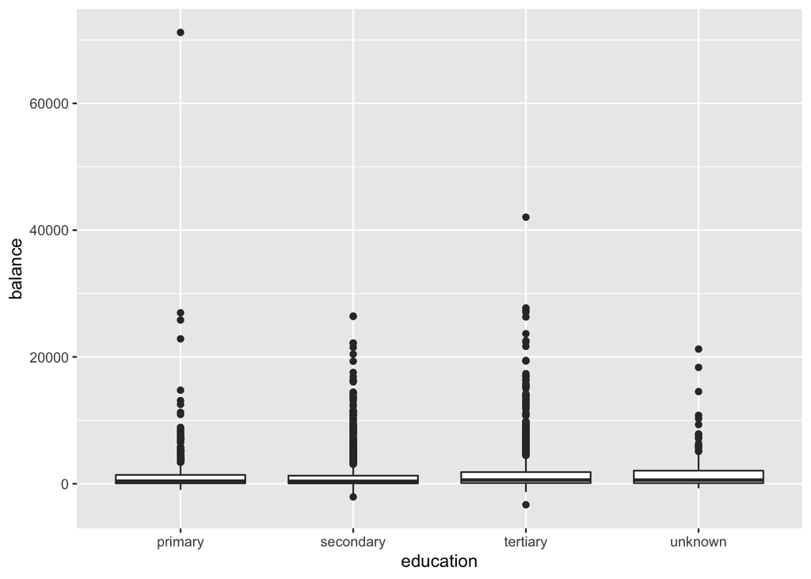

```r
# Find the relationship between balance and education
ggplot(bank) +
  geom_boxplot(mapping = aes(x = education, y = balance))
```

# Finding 5

The number of people divorced in 30s,40s and 50s are similar but the single number of the single decreases with age increasing.

```r
# Find the relationship between age and marital
bank <- mutate(bank,age_group = (age %/% 10) * 10)
bank %>%
  dplyr::filter(marital=="married")  %>%
  group_by(age_group) %>%
  summarise(num = n()) -> res1
bank %>%
group_by(age_group) %>%
summarise(total = n()) -> res2
res <- full_join(res1,res2,by = "age_group")
res <- mutate(res, `marriage rate` = num/total)
res
```

```
## # A tibble: 8 x 4
##   age_group   num total `marriage rate`
##       <dbl> <int> <int>           <dbl>
## 1        20   129   478           0.270
## 2        30  1023  1808           0.566
## 3        40   854  1203           0.710
## 4        50   653   854           0.765
## 5        60    91   113           0.805
## 6        70    36    47           0.766
## 7        80    11    14           0.786
## 8        10    NA     4          NA
```

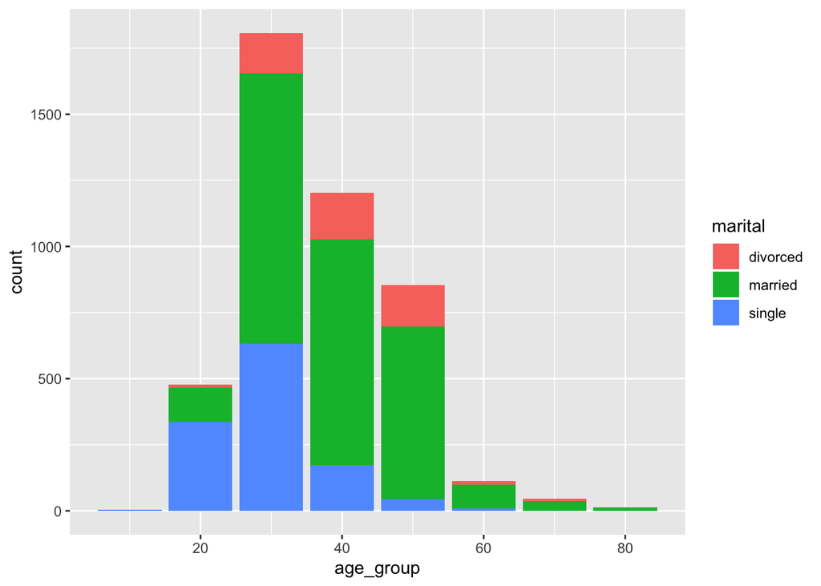

```r
ggplot() +
  geom_bar(data = bank, mapping = aes(x = age_group, fill = marital))
```

# Finding 6

The education level varies among jobs(excluding students and unknown).

The **managers** has the *highest* education leve, more than 75% of which has tertiary education.

The **housemaids** has the **lowest** education leve, nearly half of whom only get primary education.

```r
# Find the relationship between job and education
bank %>%
group_by(job,education) %>%
summarise(num = n()) %>%
  spread(education, num) -> res
res
```

```
## # A tibble: 12 x 5
## # Groups:   job [12]
##    job           primary secondary tertiary unknown
##    <fct>           <int>     <int>    <int>   <int>
##  1 admin.             17       393       51      17
##  2 blue-collar       369       524       12      41
##  3 entrepreneur       26        58       73      11
##  4 housemaid          57        28       22       5
##  5 management         39       116      787      27
##  6 retired            80       105       31      14
##  7 self-employed      15        76       88       4
##  8 services           25       363       16      13
##  9 student             2        47       19      16
## 10 technician         15       520      211      22
## 11 unemployed         26        68       32       2
## 12 unknown             7         8        8      15
```

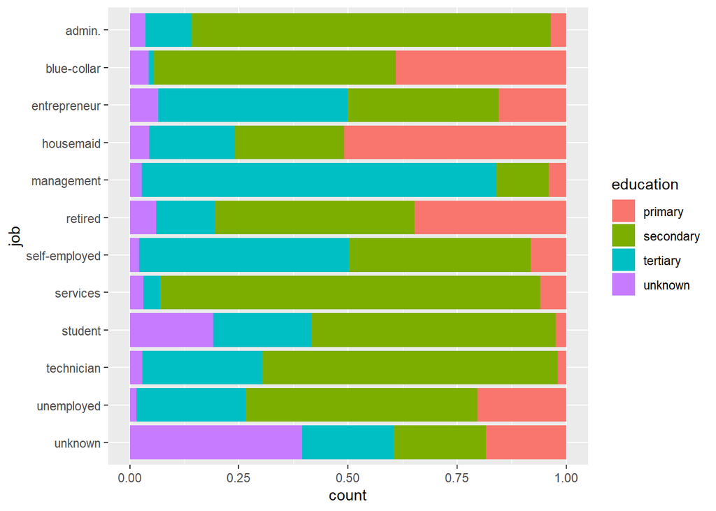

```r
ggplot() +
  geom_bar(data = bank, mapping = aes(x = job, fill = education),position = "fill") +
  scale_x_discrete(limit = rev(levels(bank$job))) +
  coord_flip()
```

# Finding 7

People who have personal loan have only around 55% of balance than those who don’t have personal loan. Housing loan has slight bad effects on people’s balance condition. People prefer not owning liabilities

```r
# Find the relationship between balance and loans
bank %>%
group_by(housing,loan) %>%
  summarise(average = mean(balance), median = median(balance)) -> res
res
```

```
## # A tibble: 4 x 4
## # Groups:   housing [2]
##   housing loan  average median
##   <fct>   <fct>   <dbl>  <dbl>
## 1 no      no      1709.    502
## 2 no      yes      929.    276
## 3 yes     no      1362.    472
## 4 yes     yes      909.    278
```

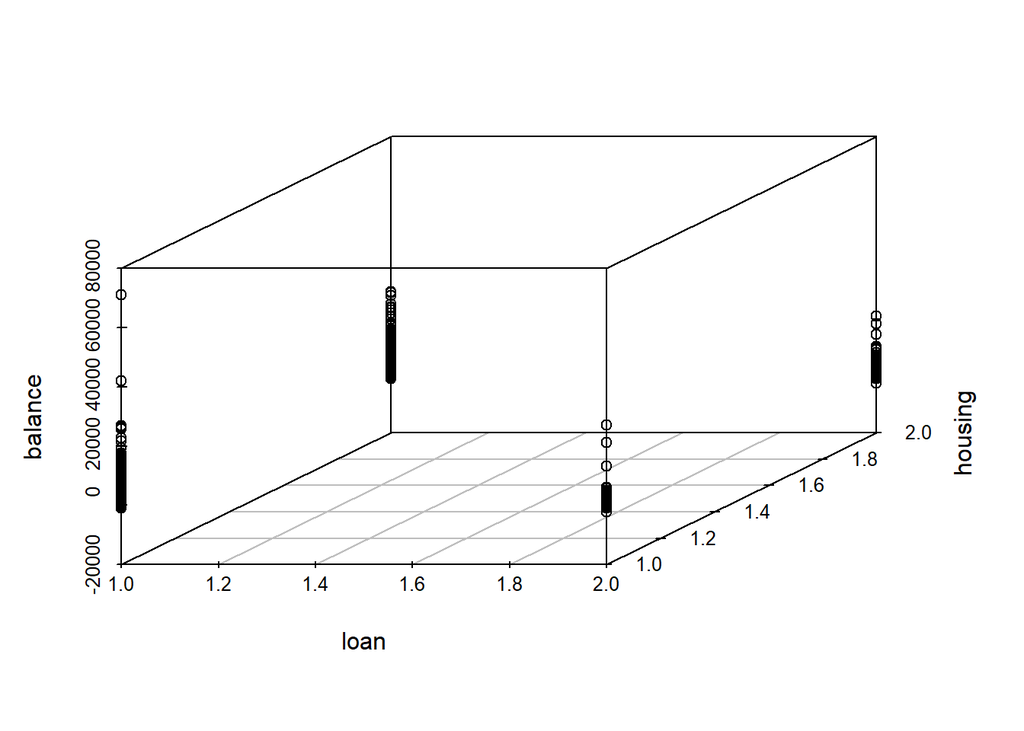

```r
library(scatterplot3d)
with(bank,{scatterplot3d(x = loan, y = housing, z = balance)})
```

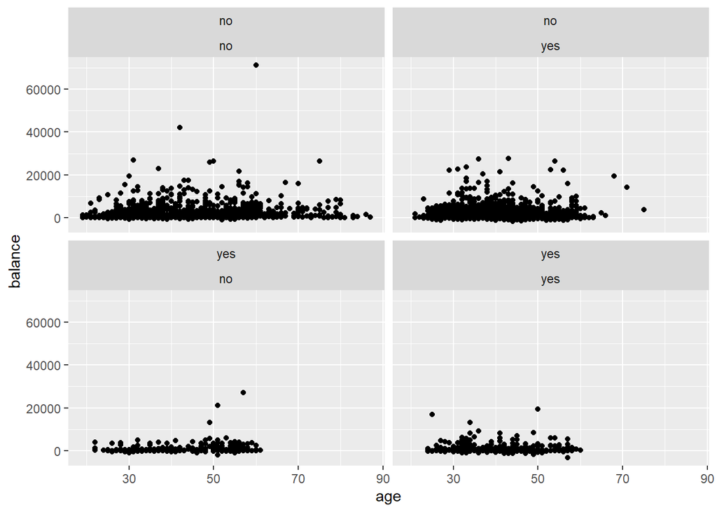

```r
ggplot(data = bank) +
  geom_point(mapping = aes(x = age, y = balance)) +
  facet_wrap(loan ~ housing, nrow = 2)
```

# Finding 8

People who don’t have credit in default are in a **much better** balance condition compared with those who have credit in default, but have huge variation.

```r
# Find the relationship between default and balance
bank %>%
group_by(default) %>%
summarise(average = mean(balance), max = max(balance), min = min(balance), median = median(balance)) -> res
res
```

```
## # A tibble: 2 x 5
##   default average   max   min median
##   <fct>     <dbl> <int> <int>  <dbl>
## 1 no        1451. 71188 -1746    462
## 2 yes       -209.  1238 -3313    -19
```

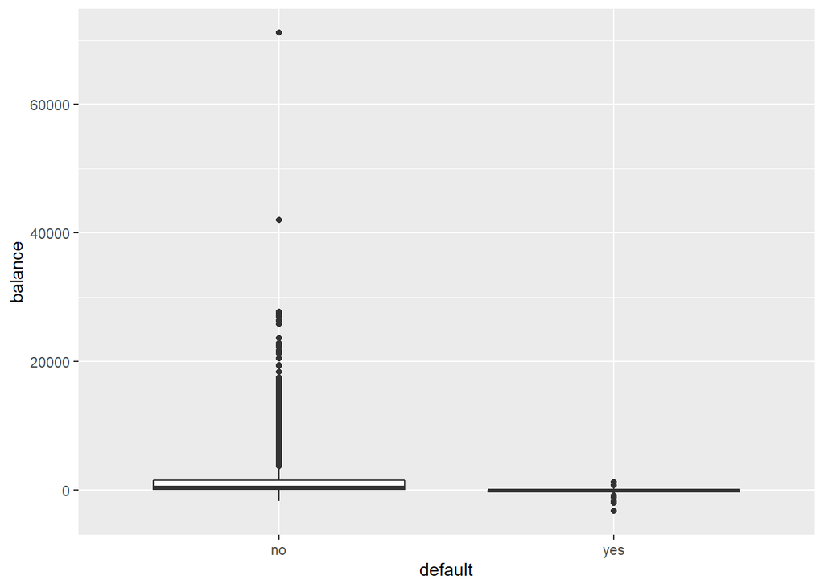

```r
ggplot(bank, aes(default, balance)) +
  geom_boxplot()
```

# Finding 9

The most common type of contact communication is by cellular.

The last contact durations of all three types concentrates around 175 seconds.

Generally, the last durations by *cellular* is the **longest** while that by *telephone* is the **shortest**.

```r
# Find the relationship between contact type and duration
bank %>%
group_by(contact) %>%
summarise(num = n(),average = mean(duration), max = max(duration), min = min(duration), median = median(duration)) -> res
res
```

```
## # A tibble: 3 x 6
##   contact     num average   max   min median
##   <fct>     <int>   <dbl> <int> <int>  <dbl>
## 1 cellular   2896    267.  3025     5   188
## 2 telephone   301    243.  1971     5   164
## 3 unknown    1324    262.  2769     4   184.
```

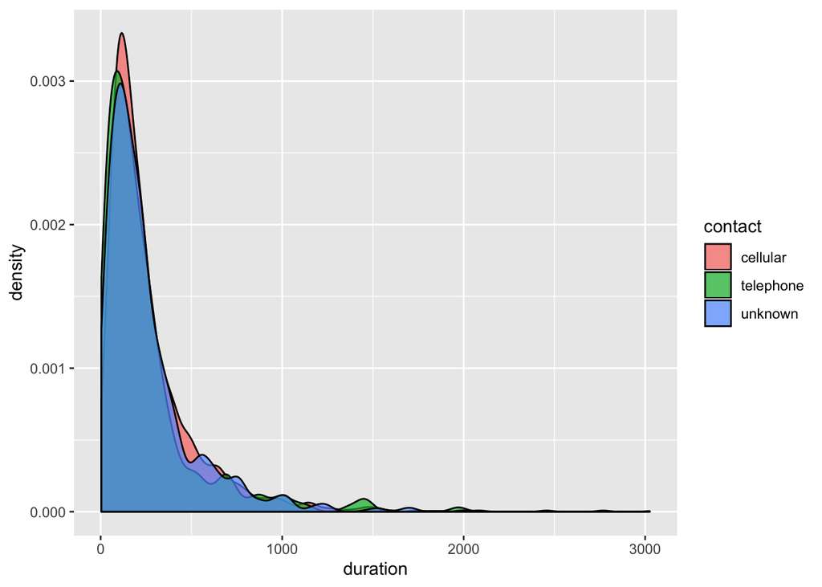

```r
ggplot(bank, aes(duration)) + geom_density(aes(fill = contact), alpha = 0.7)
```

# Finding 10

In the previous marketing campaign，most of people gets secondory and tertiary education.

Generally, the **higher** educaion one gets, telemarketing has the **higher** possibility to success and **lower** possibility to fail, though *not significantly*.

```r
# outcome of the previous marketing campaign
bank %>%
  group_by(education, poutcome) %>%
  summarise(num = n()) %>%
  spread(poutcome, num)-> res
res
```

```
## # A tibble: 4 x 5
## # Groups:   education [4]
##   education failure other success unknown
##   <fct>       <int> <int>   <int>   <int>
## 1 primary        61    22      15     580
## 2 secondary     253   102      60    1891
## 3 tertiary      157    65      44    1084
## 4 unknown        19     8      10     150
```

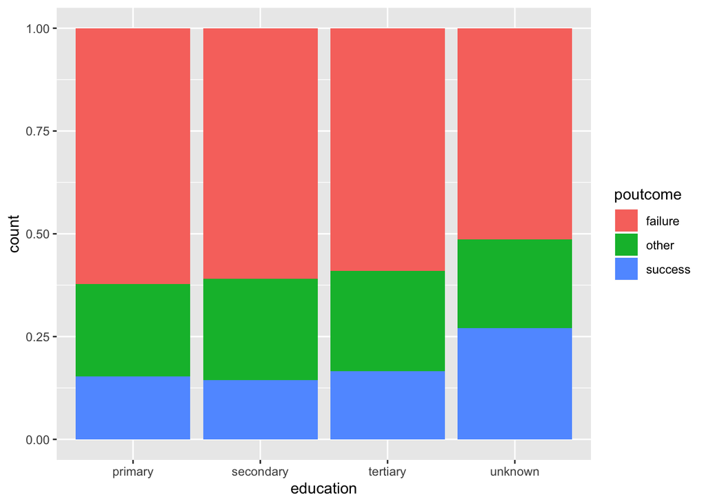

```r
ggplot() +
  geom_bar(data = dplyr::filter(bank, poutcome !="unknown"), mapping = aes(x = education, fill = poutcome),position = "fill")
```